# Ensembling Procedure

### Ensemble of Classifcation Algorithms

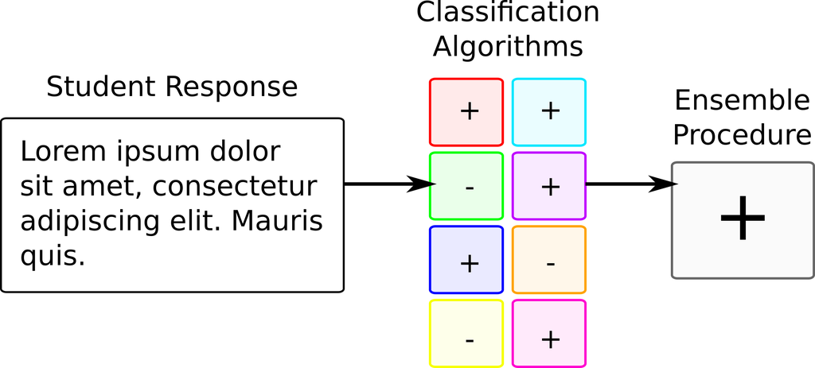

### The Problem

**Individual algorithms perform better/worse on certain types of prompt/rubric pairs**

One Solution:

- Manually select which algorithms to use in the ensemble

### The Problem with the Solution

Good, except for:

- Manual selection challenging and time consuming
- Even lesser algorithms contribute when used in aggregate

### Another Solution

**A Smarter Ensembling Proceedure**

Let the system select (or bettering yet assign weights to) the individual classifiers during the training of a scoring model

### Current Solution: Simple Voting

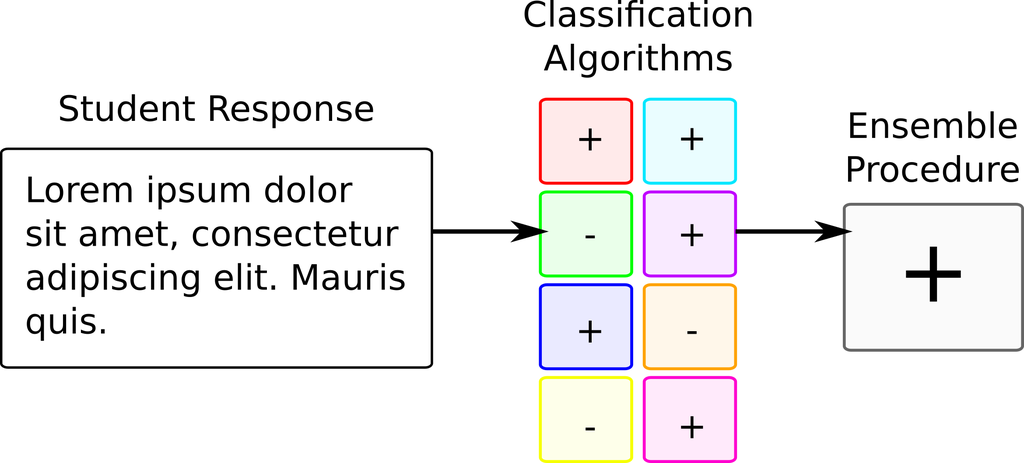

### One Better: Leverage Scoring Probability

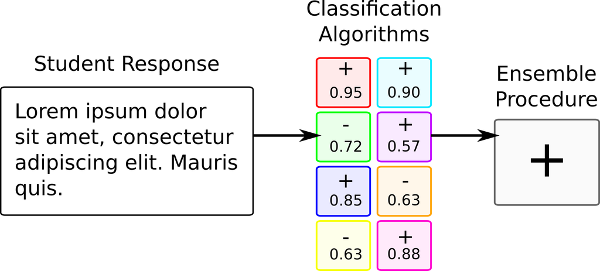

### First Approach: Probabilty Weighted Voting

**Select the score with the highest aggregate probability**

Example: 3 Algorithms with positive/negative classification

|  | Algorithm 1 | Algorithm 2 | Algorithm 3 | Total |
| --- | --- | --- | --- | --- |
| Postive | 0.52 | 0.55 | 0.3 | 1.37 |
| Negative | 0.48 | 0.45 | 0.7 | 1.63 |

### Probabilty Weighted Voting

**Select the score with the highest aggregate probability**

*Pros*

- Fast/Cheap/Simple
- Leverages self reported probabilities

*Cons*

- Leverages self reported probabilites

### A Second Approach: Ensembling Classifier

**Fit a secondary classifier that uses probabilites as features**

A secondary classifier would:

- Select which algorithms to use as input
- Weight the input classifiers based on predictive power
- Utalize probabilities in a more sofisticated manner

### A Second Approach: Ensembling Classifier

**Fit a secondary classifier that uses probabilites as features**

Caveats

- More computationally intense
- Reduce the amount of data availible to primary classifiers

### More Specifically: Penalized Logistic Regression

**Penalized Logistic Regression**

- Logistic regression with weighting
- Designed to minimized overfitting with lots of features
- Effectively limits influence of features with low predictive power

### Limitations of Current System

**In the current implementation each individual a score and an associated probability**

Example: Data returned by a single classifier for a 3 level holistic rubric

[output not shown]

### Limitations of Current System

**In the current implementation each individual a score and an associated probability**

To construct a complete feature set for this example we would need probabilites

| Bin 1 | Bin 2 | Bin 3 |
| --- | --- | --- |
| 0.95 | 0.02 | 0.03 |
| 0.33 | 0.40 | 0.27 |
| 0.13 | 0.72 | 0.15 |
| 0.07 | 0.05 | 0.88 |
| 0.67 | 0.21 | 0.12 |

### Limitations of Current System

*Thus* within current framework either weighted voting or PLR ensembling may only be performed with on analytic rubrics with positive/negtive coded bins

### Limitations of Current System

*Thus* within current framework either weighted voting or PLR ensembling may only be performed with on analytic rubrics with positive/negtive coded bins

These limits are *not* tied to the algorithms, but to the implementation

### Testing: Weight Loss

N=1175

Cross Validation Kappa Values

| Human | Simple | Weighted | PLR L2 | PLR L1 |
| --- | --- | --- | --- | --- |
| 385 | 0.955 | 0.957 | 0.956 | 0.956 |
| 10 | 0.181 | 0.459 | -0.002 | 0.000 |
| 99 | 0.387 | 0.512 | 0.621 | 0.586 |
| 478 | 0.695 | 0.707 | 0.733 | 0.727 |
| 10 | 0.000 | 0.000 | 0.000 | 0.000 |
| 219 | 0.857 | 0.880 | 0.889 | 0.886 |

### Testing: Root Cell

N=677 Cross Validation Kappa Values

| Human | Simple | Weighted | PLR L2 | PLR L1 |
| --- | --- | --- | --- | --- |
| 175 | 0.795 | 0.827 | 0.809 | 0.805 |
| 127 | 0.812 | 0.838 | 0.828 | 0.803 |
| 69 | 0.738 | 0.755 | 0.681 | 0.626 |
| 139 | 0.878 | 0.908 | 0.895 | 0.884 |
| 110 | 0.580 | 0.608 | 0.610 | 0.606 |

### Testing: Grape

N=317

Cross Validation Kappa Values

| Human | Simple | Weighted | PLR L2 | PLR L1 |
| --- | --- | --- | --- | --- |
| 161 | 0.861 | 0.905 | 0.905 | 0.912 |
| 56 | 0.712 | 0.813 | 0.814 | 0.812 |
| 28 | 0.364 | 0.509 | 0.680 | 0.595 |
| 62 | 0.562 | 0.671 | 0.774 | 0.791 |
| 67 | 0.630 | 0.694 | 0.740 | 0.800 |

### Testing: Non-coding Mutation

N=301 Cross Validation Kappa Values

| Human | Simple | Weighted | PLR L2 | PLR L1 |
| --- | --- | --- | --- | --- |
| 224 | 0.729 | 0.727 | 0.706 | 0.693 |
| 183 | 0.818 | 0.795 | 0.768 | 0.762 |
| 35 | 0.734 | 0.779 | 0.755 | 0.800 |
| 45 | 0.427 | 0.531 | 0.489 | 0.493 |
| 38 | 0.596 | 0.652 | 0.525 | 0.583 |
| 55 | 0.835 | 0.861 | 0.824 | 0.794 |
| 38 | 0.422 | 0.475 | 0.300 | 0.208 |

### Preliminary Results

**Leveraging prediction \( \Longrightarrow \) higher performance models**

- **Probability Weighted Voting preferred** for under sampled feature space; more data is better
- **PLR preferred** well sampled feature space; identifying best predictors better
- No clear preferred PLR penalty structure